# _15_05_2021

## Python Pandas Visualization

**Basic Plotting: plot**

> This functionality on Series and DataFrame is just a simple wrapper around the matplotlib libraries plot() method.

```
original data frame
             A   B   C   D
2021-02-02   3   9  14  12
2021-02-03  17  10  14   5
2021-02-04   0   5   2  10
2021-02-05  11  14  15  17
2021-02-06   5  11  13  12
2021-02-07  17   4   9   1
2021-02-08   3  15   4   1
2021-02-09  13  10   3   8
2021-02-10  13   4   5   6
---------------------------------------------------------
```

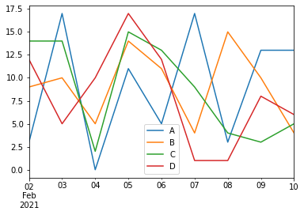

```python
import pandas as pd
import numpy as np

df1 = pd.DataFrame(np.random.randint(19,size=(9,4)),index=pd.date_range('2021-02-02',periods=9),
                   columns=list('ABCD'))

printfn('original data frame',df1)

# plotting the data frame
df1.plot()
```

> If the index consists of dates, it calls gct().autofmt_xdate() to format the x-axis as shown in the above illustration.

> We can plot one column versus another using the x and y keywords.

> Plotting methods allow a handful of plot styles other than the default line plot. These methods can be provided as the kind keyword argument to plot(). These include −
- bar or barh for bar plots
- hist for histogram
- box for boxplot
- 'area' for area plots
- 'scatter' for scatter plots

**Bar Plot**

> Let us now see what a Bar Plot is by creating one. A bar plot can be created in the following way −

```
bar dataframe chart
------------------------------------------------------------------
------------------------------------------------------------------
------------------------------------------------------------------
```

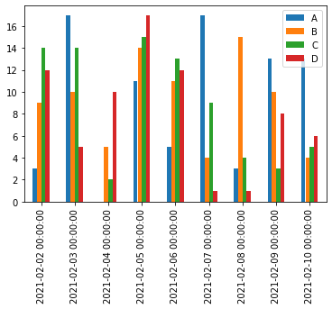

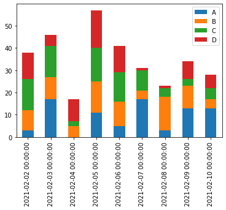

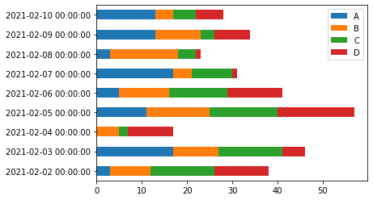

```python
print('bar dataframe chart')
df1.plot.bar()
print('------------------------------------------------------------------')

# To produce a stacked bar plot, pass stacked=True −
df1.plot.bar(stacked=True)
print('------------------------------------------------------------------')

# to produce a stacked bar plot on horizontal
df1.plot.barh(stacked=True)
print('------------------------------------------------------------------')
```

```
array([[<matplotlib.axes._subplots.AxesSubplot object at 0x7fdceb8b1990>,
      dtype=object)
```

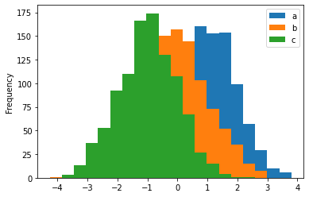

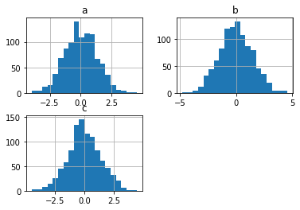

```python
# Histograms
# Histograms can be plotted using the plot.hist() method. We can specify number of bins.

df2 = pd.DataFrame({'a':np.random.randn(1000)+1,'b':np.random.randn(1000),'c':np.random.randn(1000)-1})

# histogram plot
df2.plot.hist(bins=20)

## to plot diff plot for diff columns
df2.diff().hist(bins=20)
```

> Boxplot can be drawn calling Series.box.plot() and DataFrame.box.plot(), or DataFrame.boxplot() to visualize the distribution of values within each column.

```
box plot
Area plot
```

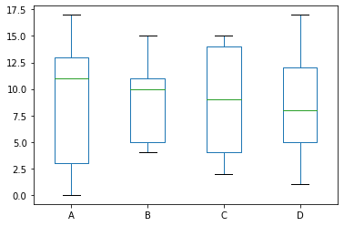

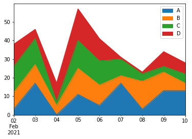

```python
print('box plot')
df1.plot.box()

# Area plot can be created using the Series.plot.area() or the DataFrame.plot.area() methods.

print('Area plot')
df1.plot.area()
```

```
Scatter plot
```

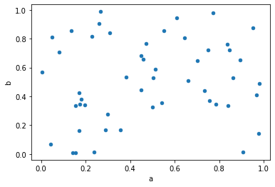

```python
print('Scatter plot')
df = pd.DataFrame(np.random.rand(50, 4), columns=['a', 'b', 'c', 'd'])

df.plot.scatter(x='a', y='b');
```

```
pie chart
```

```
array([<matplotlib.axes._subplots.AxesSubplot object at 0x7fdceb761c90>,
      dtype=object)
```

[figure not shown]

```python
print('pie chart')
df1.plot.pie(subplots=True)
```

## Python Pandas IO Tools

> The Pandas I/O API is a set of top level reader functions accessed like pd.read_csv() that generally return a Pandas object.

> The two workhorse functions for reading text files (or the flat files) are read_csv() and read_table(). They both use the same parsing code to intelligently convert tabular data into a DataFrame object −

```
pandas.read_csv(filepath_or_buffer, sep=',', delimiter=None, header='infer',
names=None, index_col=None, usecols=None
```

```
pandas.read_csv(filepath_or_buffer, sep='\t', delimiter=None, header='infer',
names=None, index_col=None, usecols=None
```

Here is how the csv file data looks like −

S.No,Name,Age,City,Salary 1,Tom,28,Toronto,20000 2,Lee,32,HongKong,3000 3,Steven,43,Bay Area,8300 4,Ram,38,Hyderabad,3900

https://towardsdatascience.com/3-ways-to-load-csv-files-into-colab-7c14fcbdcb92#:~:text=2)%20From%20a%20local%20drive&text=Click%20on%20%E2%80%9CChoose%20Files%E2%80%9D%20then,name%20of%20the%20uploaded%20file).[link text]

```python
# read.csv
# read.csv reads data from the csv files and creates a DataFrame object.

from google.colab import files
import io

uploaded = files.upload()

# since using colab
df2 = pd.read_csv(io.BytesIO(uploaded['temp.csv']))

# for local editors
# df=pd.read_csv("temp.csv")
```

Upload widget is only available when the cell has been executed in the current browser session. Please rerun this cell to enable.

```
Saving temp.csv to temp.csv
```

```python
printfn('data frame from csv file',df2)

# custom index
# This specifies a column in the csv file to customize the index using index_col.
# df=pd.read_csv("temp.csv", index_col=['S.No'])

# changes index based on S.No
df2 = pd.read_csv(io.BytesIO(uploaded['temp.csv']), index_col=['S.No'])
printfn('df index on S no',df2)
# Converters
# dtype of the columns can be passed as a dict.

# df = pd.read_csv("temp.csv", dtype={'Salary': np.float64})
df2 = pd.read_csv(io.BytesIO(uploaded['temp.csv']), dtype={'Salary': np.float64})
printfn('df salary converted to float',df2)

printfn('data types in df',df.dtypes)
# By default, the dtype of the Salary column is int, but the result shows it as float because we have explicitly casted the type.
# Thus, the data looks like float −
```

[output not shown]

**header_names**

> Specify the names of the header using the names argument.

Observe, the header names are appended with the custom names, but the header in the file has not been eliminated. Now, we use the header argument to remove that.

If the header is in a row other than the first, pass the row number to header. This will skip the preceding rows.

#### df=pd.read_csv("temp.csv",names=['a','b','c','d','e'],header=0)

```python
df2 = pd.read_csv(io.BytesIO(uploaded['temp.csv']), names=['a','b','c','d','e'])
printfn('df  with new header',df2)

df2 = pd.read_csv(io.BytesIO(uploaded['temp.csv']), names=['a','b','c','d','e'],header=0)
printfn('df  with new header replaced old header',df2)
```

```
df  with new header
      a       b    c          d       e
0  S.No    Name  Age       City  Salary
1     1     Tom   28    Toronto   20000
2     2     Lee   32   HongKong    3000
3     3  Steven   43   Bay Area    8300
4     4     Ram   38  Hyderabad    3900
---------------------------------------------------------
df  with new header replaced old header
   a       b   c          d      e
0  1     Tom  28    Toronto  20000
1  2     Lee  32   HongKong   3000
2  3  Steven  43   Bay Area   8300
3  4     Ram  38  Hyderabad   3900
---------------------------------------------------------
```

```python
# skiprows
# skiprows skips the number of rows specified.
df2 = pd.read_csv(io.BytesIO(uploaded['temp.csv']), skiprows=2)
printfn('df  with first two rows skipped',df2)
```

```
df  with first two rows skipped
   2     Lee  32   HongKong  3000
0  3  Steven  43   Bay Area  8300
1  4     Ram  38  Hyderabad  3900
---------------------------------------------------------
```

## Python Pandas Sparse Data

Sparse objects are “compressed” when any data matching a specific value (NaN / missing value, though any value can be chosen) is omitted. A special SparseIndex object tracks where data has been “sparsified”. This will make much more sense in an example. All of the standard Pandas data structures apply the to_sparse method −

```python
import pandas as pd
import numpy as np

ss = pd.Series(np.random.randint(9,size=9))
printfn('Original series',ss)

ss[2:8]=np.nan
printfn('Series with nan',ss)

ts = pd.Series(np.random.randn(10))
ts[2:-2] = np.nan
sts = ts.to_sparse()
print(sts)
```

```
Original series
0    4
1    7
2    8
3    0
4    8
5    2
6    3
7    6
8    1
dtype: int64
---------------------------------------------------------
Series with nan
0    4.0
1    7.0
2    NaN
3    NaN
4    NaN
5    NaN
6    NaN
7    NaN
8    1.0
dtype: float64
---------------------------------------------------------
```

[output not shown]